# Bolas_lab14_GWR

Ellie, GEO200CN, Spring 2017

May 31, 2017

# Geographically Weighted Regressions

## Re-fit OLS

```r
library(maptools)
library(rgdal)
library(raster)
library(latticeExtra)
#read in data
datapath<-"C:/Users/ebola/Google Drive/Git/GEO200CN/data/ROI"
ROI <- readOGR(dsn=datapath, layer = "geo200cn_ROI", integer64 = "allow.loss")
#remove missing data
ROI <- ROI[!is.na(ROI@data$moppl2),]

#fit OLS model
OLSlm <- lm(moppl2~ecppl1 + hsppl1 + ecplc1 + enplc4, data=ROI)
summary(OLSlm)
```

```
##
## Call:
## lm(formula = moppl2 ~ ecppl1 + hsppl1 + ecplc1 + enplc4, data = ROI)
##
## Residuals:
##     Min      1Q  Median      3Q     Max
## -36.290  -7.153   0.143   7.818  37.100
##
## Coefficients:
##              Estimate Std. Error t value Pr(>|t|)
## (Intercept)  6.441628   8.173295   0.788 0.430847
## ecppl1       0.289194   0.076894   3.761 0.000181 ***
## hsppl1      -0.204586   0.021262  -9.622  < 2e-16 ***
## ecplc1       0.012797   0.001111  11.523  < 2e-16 ***
## enplc4       3.212283   0.348335   9.222  < 2e-16 ***
## ---
## Signif. codes:  0 '***' 0.001 '**' 0.01 '*' 0.05 '.' 0.1 ' ' 1
##
## Residual standard error: 11.18 on 824 degrees of freedom
## Multiple R-squared:  0.3149, Adjusted R-squared:  0.3116
## F-statistic:  94.7 on 4 and 824 DF,  p-value: < 2.2e-16
```

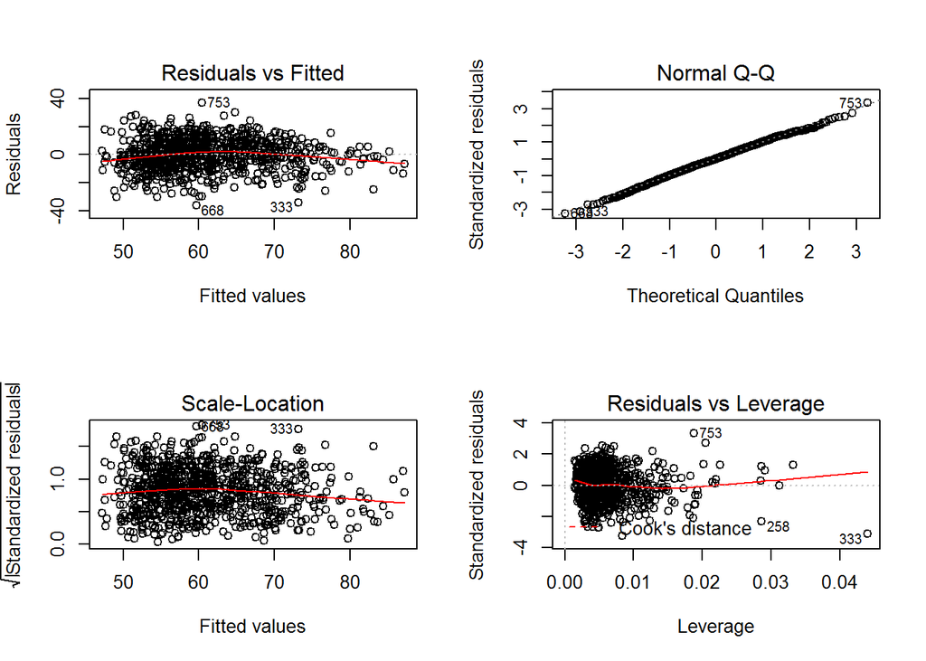

```r
#look at residuals
par(mfrow = c(2, 2))
plot (OLSlm)
```

```r
#BP Test
library (lmtest)
bptest (OLSlm)
```

```
##
##  studentized Breusch-Pagan test
##
## data:  OLSlm
## BP = 9.4831, df = 4, p-value = 0.05009
```

```r
#Make spatial weights to calculate Moran's I of residuals (not of the original data)
library(spdep)
xy <- coordinates(ROI)
nb2500 <- dnearneigh(xy, 0, 2500) #neighborlist
w2500 <- nb2listw(nb2500, zero.policy=TRUE) #gives spatial weights to list
print(w2500, zero.policy=TRUE)
```

```
## Characteristics of weights list object:
## Neighbour list object:
## Number of regions: 829
## Number of nonzero links: 4454
## Percentage nonzero weights: 0.6480987
## Average number of links: 5.372738
## 107 regions with no links:
## 8 24 25 26 30 37 73 107 257 258 259 296 297 299 322 326 327 353 354 356 361 364 374 375 376 380 382 390 391 392 393 395 396 397 411 423 424 425 427 428 436 437 442 477 478 479 480 481 501 502 509 513 521 524 526 527 528 529 545 546 547 548 549 555 562 574 584 585 618 623 632 633 634 635 648 653 6…
##
## Weights style: W
## Weights constants summary:
##     n     nn  S0       S1     S2
## W 722 521284 722 340.8153 2975.7
```

```r
lm.morantest (OLSlm, w2500, zero.policy=TRUE)
```

```
##
##  Global Moran I for regression residuals
##
## data:
## model: lm(formula = moppl2 ~ ecppl1 + hsppl1 + ecplc1 + enplc4,
## data = ROI)
## weights: w2500
##
## Moran I statistic standard deviate = 17.535, p-value < 2.2e-16
## alternative hypothesis: greater
## sample estimates:
## Observed Moran I      Expectation         Variance
##     0.4409669549    -0.0041772206     0.0006444474
```

```r
#add residuals to ROI and then map them as polygons
OLSresidDF <- as.data.frame (resid(OLSlm))
ROI$OLSresid <- OLSresidDF$"resid(OLSlm)" #tells it you want the column name, not to do the function
str(OLSresidDF)
```

```
## 'data.frame':    829 obs. of  1 variable:
##  $ resid(OLSlm): num  14.421 26.338 11.96 10.218 0.502 ...
```

```r
head(ROI)
```

```
##   STATEFP10 COUNTYFP10 TRACTCE10     GEOID10 NAME10          NAMELSAD10
## 0        06        113    010513 06113010513 105.13 Census Tract 105.13
## 1        06        113    010512 06113010512 105.12 Census Tract 105.12
## 2        06        113    010511 06113010511 105.11 Census Tract 105.11
## 3        06        113    010402 06113010402 104.02 Census Tract 104.02
## 4        06        113    010312 06113010312 103.12 Census Tract 103.12
## 5        06        113    010310 06113010310 103.10 Census Tract 103.10
##   MTFCC10 FUNCSTAT10  ALAND10 AWATER10  INTPTLAT10   INTPTLON10 moppl2
## 0   G5020          S   647507        0 +38.5499958 -121.7837160  76.83
## 1   G5020          S  1191814        0 +38.5524621 -121.7731005  85.09
## 2   G5020          S   870796        0 +38.5577814 -121.7797140  73.83
## 3   G5020          S 19261893  1350475 +38.5075686 -121.5653106  67.32
## 4   G5020          S  2463360        0 +38.5444338 -121.5522110  73.78
## 5   G5020          S  4769176   306237 +38.5451518 -121.5770403  69.10
##   cntyname density ecppl1 hsppl1 ecplc1 hsplc2 enplc4   OLSresid
## 0     Yolo      HD     90     32    592      0      9 14.4212287
## 1     Yolo      HD     90     50    594      0      9 26.3381852
## 2     Yolo      HD     93     39    594      0      9 11.9601557
## 3     Yolo      HD     91     86    767      0     10 10.2179073
## 4     Yolo      HD     93     71   1746      0     10  0.5023438
## 5     Yolo      HD     95     69   1601      0     10 -3.3096336
```

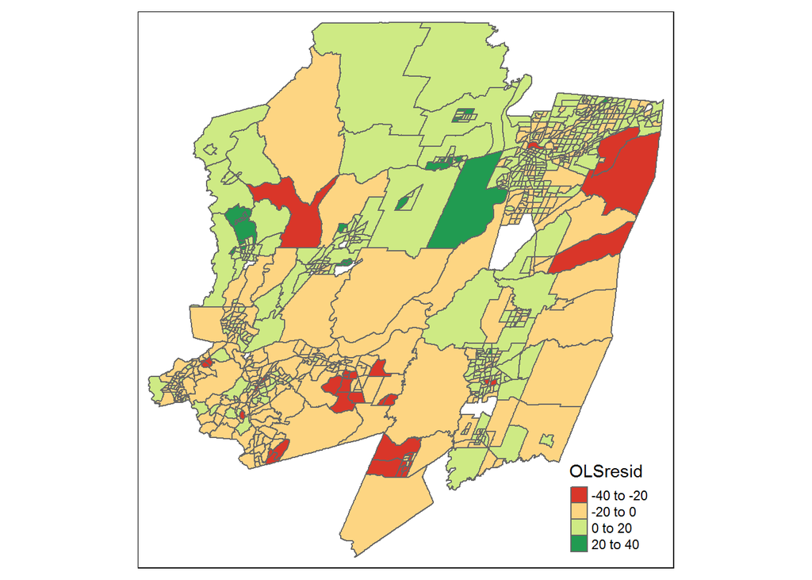

```r
library (tmap)
qtm (shp=ROI,  fill="OLSresid", fill.palette="div")
```

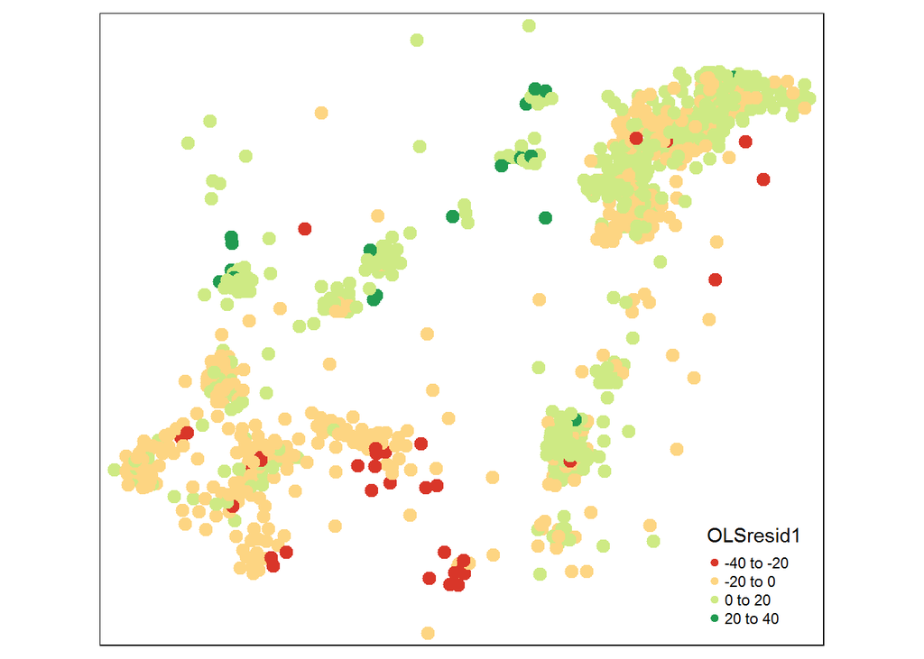

```r
#or plot residuals as points using centroid coordinates
OLSresid1 <- resid(OLSlm)
MAPresids = SpatialPointsDataFrame(data=data.frame(OLSresid1), coords=xy, proj4string=CRS("+proj=robin +lon 0=0"))
qtm (shp=MAPresids, symbols.col="OLSresid1", symbols.shape=20)
```

## Global Spatial Regression Model

```r
#Run the Lagrange Multiplier test to select between a Spatial Lag and Spatial Error model
lm.LMtests(OLSlm, w2500, zero.policy=TRUE, test = 'all')
```

```
##
##  Lagrange multiplier diagnostics for spatial dependence
##
## data:
## model: lm(formula = moppl2 ~ ecppl1 + hsppl1 + ecplc1 + enplc4,
## data = ROI)
## weights: w2500
##
## LMerr = 392.1, df = 1, p-value < 2.2e-16
##
##
##  Lagrange multiplier diagnostics for spatial dependence
##
## data:
## model: lm(formula = moppl2 ~ ecppl1 + hsppl1 + ecplc1 + enplc4,
## data = ROI)
## weights: w2500
##
## LMlag = 101.76, df = 1, p-value < 2.2e-16
##
##
##  Lagrange multiplier diagnostics for spatial dependence
##
## data:
## model: lm(formula = moppl2 ~ ecppl1 + hsppl1 + ecplc1 + enplc4,
## data = ROI)
## weights: w2500
##
## RLMerr = 303.24, df = 1, p-value < 2.2e-16
##
##
##  Lagrange multiplier diagnostics for spatial dependence
##
## data:
## model: lm(formula = moppl2 ~ ecppl1 + hsppl1 + ecplc1 + enplc4,
## data = ROI)
## weights: w2500
##
## RLMlag = 12.898, df = 1, p-value = 0.000329
##
##
##  Lagrange multiplier diagnostics for spatial dependence
##
## data:
## model: lm(formula = moppl2 ~ ecppl1 + hsppl1 + ecplc1 + enplc4,
## data = ROI)
## weights: w2500
##
## SARMA = 405, df = 2, p-value < 2.2e-16
```

```r
# focus on signiﬁcance of the tests represented by the p-value, and ﬁrst examine the     simple tests if either of those are siginifant you start with that form of spatial regession, if both are   siginiﬁcant look at the results of the robust tests

#both the simple and the robust tests were significant, but the pvalues are a little better for the spatial error model

#Spatial Error
ERRlm <-errorsarlm(moppl2~ecppl1+hsppl1+ecplc1+enplc4, data=ROI, listw=w2500, zero.policy=TRUE)
summary(ERRlm)
```

```
##
## Call:errorsarlm(formula = moppl2 ~ ecppl1 + hsppl1 + ecplc1 + enplc4,
##     data = ROI, listw = w2500, zero.policy = TRUE)
##
## Residuals:
##       Min        1Q    Median        3Q       Max
## -35.60517  -5.19248   0.98437   6.34229  25.17313
##
## Type: error
## Regions with no neighbours included:
##  8 24 25 26 30 37 73 107 257 258 259 296 297 299 322 326 327 353 354 356 361 364 374 375 376 380 382 390 391 392 393 395 396 397 411 423 424 425 427 428 436 437 442 477 478 479 480 481 501 502 509 513 521 524 526 527 528 529 545 546 547 548 549 555 562 574 584 585 618 623 632 633 634 635 648 653 …
## Coefficients: (asymptotic standard errors)
##               Estimate Std. Error z value  Pr(>|z|)
## (Intercept) 14.6864311  7.9825142  1.8398  0.065794
## ecppl1       0.1900096  0.0642855  2.9557  0.003119
## hsppl1      -0.1179787  0.0188958 -6.2437 4.274e-10
## ecplc1       0.0133086  0.0016044  8.2951 < 2.2e-16
## enplc4       2.4928803  0.4785243  5.2095 1.893e-07
##
## Lambda: 0.66306, LR test value: 308.95, p-value: < 2.22e-16
## Asymptotic standard error: 0.028877
##     z-value: 22.962, p-value: < 2.22e-16
## Wald statistic: 527.25, p-value: < 2.22e-16
##
## Log likelihood: -3020.311 for error model
## ML residual variance (sigma squared): 76.58, (sigma: 8.751)
## Number of observations: 829
## Number of parameters estimated: 7
## AIC: 6054.6, (AIC for lm: 6361.6)
```

```r
class(ERRlm)
```

```
## [1] "sarlm"
```

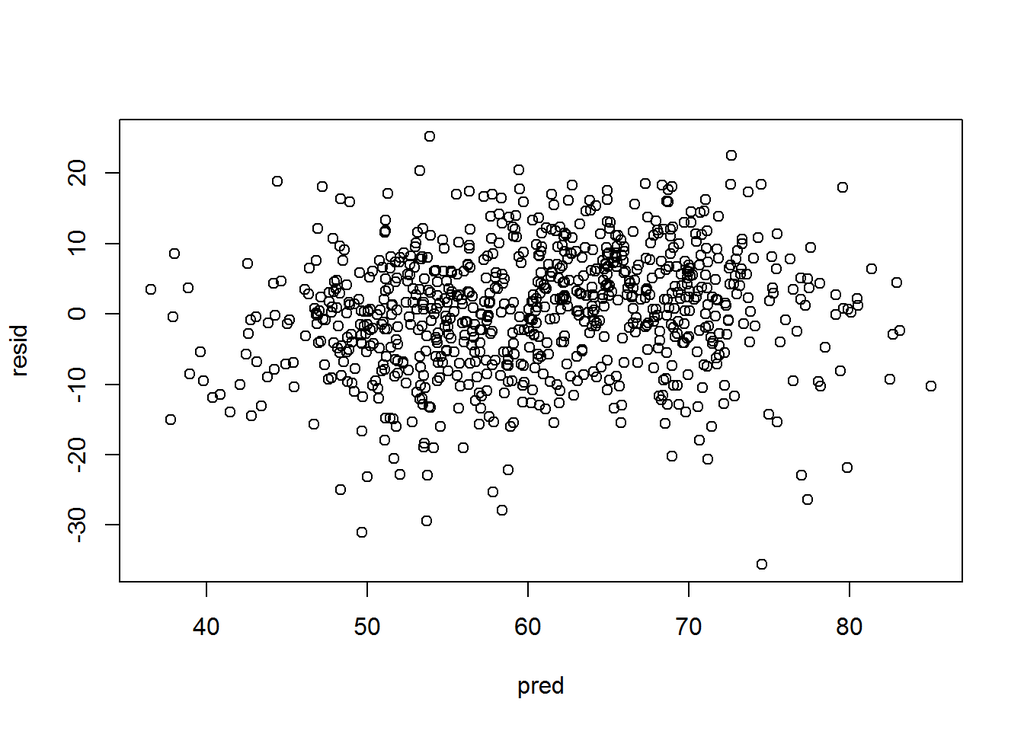

```r
#model residuals
resid <- (resid(ERRlm))
pred = predict(ERRlm, type="response")
plot (pred, resid)
```

```r
bptest.sarlm (ERRlm)
```

```
##
##  studentized Breusch-Pagan test
##
## data:
## BP = 20.452, df = 4, p-value = 0.0004065
```

```r
#BP = 20.452, df = 4, p-value = 0.0004065
moran.test (resid, w2500, zero.policy=TRUE)
```

```
##
##  Moran I test under randomisation
##
## data:  resid
## weights: w2500
##
## Moran I statistic standard deviate = -1.0231, p-value = 0.8469
## alternative hypothesis: greater
## sample estimates:
## Moran I statistic       Expectation          Variance
##     -0.0274566289     -0.0013869626      0.0006492813
```

```r
#Moran I statistic       Expectation          Variance
#    -0.0274566289     -0.0013869626      0.0006492813
#p value = .8469
```

According to the tests, the BP p-value is under 0.05, which means the there is a pattern in residual variance, or the data has heteroskasticity. However, according to the Moran’s I, the residuals are negatively spatially autocorrelated, indicating there is not a relationship between them, but this is not statistically significant.

## Local Regression: Geographically Weighted Regression

Uses kernal density estimates to define nearness, using a Gaussian (bell-shaped) kernal. We need to caluclate an optimal bandwidth, then use this to fit the GWR.

```r
#install.packages("spgwr")
library(spgwr)
```

```r
#find optimal bandwidth: For cross-validation, this scores the root mean square prediction error for the generalised geographically weighted regressions, choosing the bandwidth minimizing this quantity
bwROI <- ggwr.sel(moppl2~ecppl1+hsppl1+ecplc1+enplc4, data=ROI, gweight = gwr.Gauss,  verbose = TRUE)
```

```
## Bandwidth: 75885.9 CV score: 95443.56
## Bandwidth: 122663.4 CV score: 100373.9
## Bandwidth: 46975.83 CV score: 87554.13
## Bandwidth: 29108.42 CV score: 77281.99
## Bandwidth: 18065.76 CV score: 65875.75
## Bandwidth: 11241.02 CV score: 57701.38
## Bandwidth: 7023.093 CV score: 54507.97
## Bandwidth: 4416.274 CV score: 55501.77
## Bandwidth: 6862.494 CV score: 54411.41
## Bandwidth: 6194.296 CV score: 54128.63
## Bandwidth: 5515.152 CV score: 54104.73
## Bandwidth: 5793.607 CV score: 54076.21
## Bandwidth: 5803.481 CV score: 54076.23
## Bandwidth: 5795.314 CV score: 54076.21
## Bandwidth: 5795.186 CV score: 54076.21
## Bandwidth: 5795.185 CV score: 54076.21
## Bandwidth: 5795.185 CV score: 54076.21
## Bandwidth: 5795.185 CV score: 54076.21
## Bandwidth: 5795.185 CV score: 54076.21
## Bandwidth: 5795.185 CV score: 54076.21
```

```r
#verbose=true means it will report on its progress

#ﬁt the model using the optimal bandwidth
GWRlm <- gwr(moppl2~ecppl1+hsppl1+ecplc1+enplc4, data=ROI, bandwidth = bwROI, hatmatrix = TRUE)
GWRlm
```

```
## Call:
## gwr(formula = moppl2 ~ ecppl1 + hsppl1 + ecplc1 + enplc4, data = ROI,
##     bandwidth = bwROI, hatmatrix = TRUE)
## Kernel function: gwr.Gauss
## Fixed bandwidth: 5795.185
## Summary of GWR coefficient estimates at data points:
##                    Min.    1st Qu.     Median    3rd Qu.       Max.
## X.Intercept. -2.526e+02  3.739e+00  3.174e+01  6.542e+01  5.339e+02
## ecppl1       -2.889e+00 -8.196e-02  1.611e-01  3.478e-01  2.301e+00
## hsppl1       -1.413e+00 -1.421e-01 -6.718e-02 -2.215e-02  3.181e-01
## ecplc1       -9.013e-02  1.452e-03  9.173e-03  1.275e-02  1.117e-01
## enplc4       -2.157e+01 -1.415e+00  1.016e+00  3.777e+00  4.170e+01
##               Global
## X.Intercept.  6.4416
## ecppl1        0.2892
## hsppl1       -0.2046
## ecplc1        0.0128
## enplc4        3.2123
## Number of data points: 829
## Effective number of parameters (residual: 2traceS - traceS'S): 163.1934
## Effective degrees of freedom (residual: 2traceS - traceS'S): 665.8066
## Sigma (residual: 2traceS - traceS'S): 7.346327
## Effective number of parameters (model: traceS): 129.8997
## Effective degrees of freedom (model: traceS): 699.1003
## Sigma (model: traceS): 7.169264
## Sigma (ML): 6.583655
## AICc (GWR p. 61, eq 2.33; p. 96, eq. 4.21): 5788.585
## AIC (GWR p. 96, eq. 4.22): 5607.15
## Residual sum of squares: 35932.6
## Quasi-global R2: 0.760813
```

#### Map Results to understand spatial patterns

```r
names (GWRlm$SDF) #will show you all the available results
```

```
##  [1] "sum.w"               "X.Intercept."        "ecppl1"
##  [4] "hsppl1"              "ecplc1"              "enplc4"
##  [7] "X.Intercept._se"     "ecppl1_se"           "hsppl1_se"
## [10] "ecplc1_se"           "enplc4_se"           "gwr.e"
## [13] "pred"                "pred.se"             "localR2"
## [16] "X.Intercept._se_EDF" "ecppl1_se_EDF"       "hsppl1_se_EDF"
## [19] "ecplc1_se_EDF"       "enplc4_se_EDF"       "pred.se.1"
```

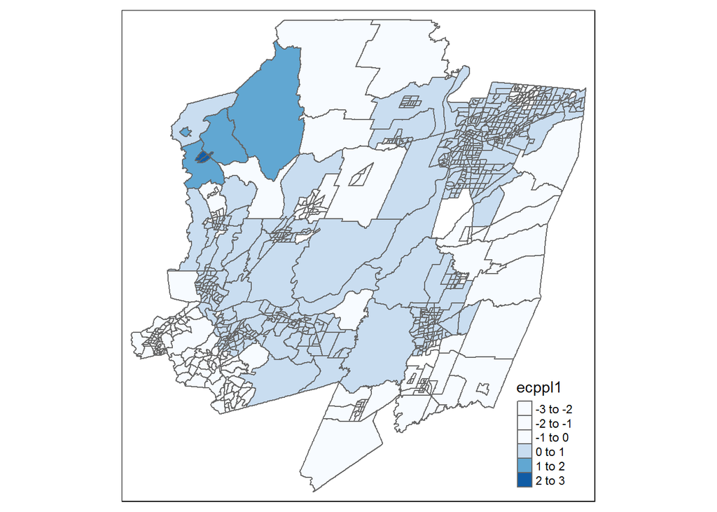

```r
#map a single variable, ecppl1
qtm (shp=GWRlm$SDF, fill="ecppl1", fill.palette="Blues")
```

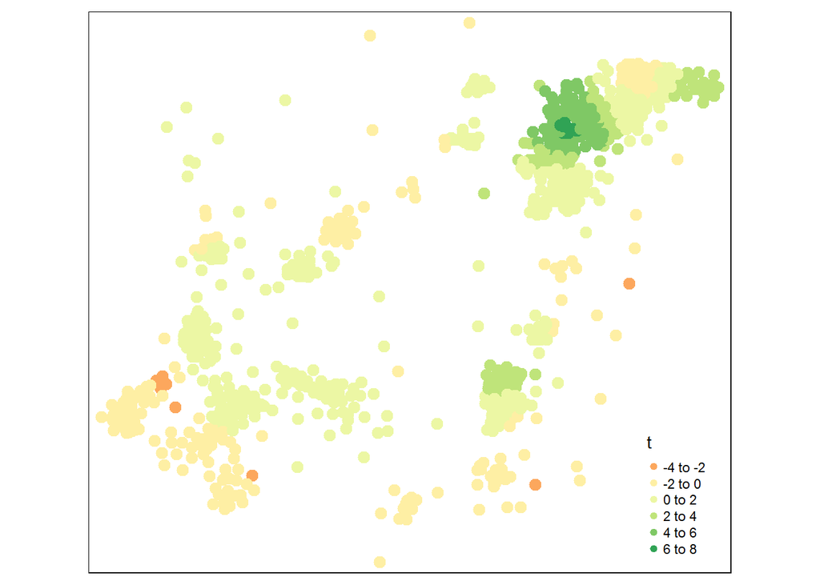

```r
#We’ll use the ﬁtted coiﬁicients and the standard error to calculate a t-statistic and map the siginicance, with |4| as our cut off for signiﬁcance
t = (GWRlm$SDF$ecppl1/GWRlm$SDF$ecppl1_se)
MAPt = SpatialPointsDataFrame(data=data.frame(t), coords=xy, proj4string=CRS("+proj=robin +lon 0=0"))
qtm (shp=MAPt, symbols.col="t", symbols.shape=20)
```

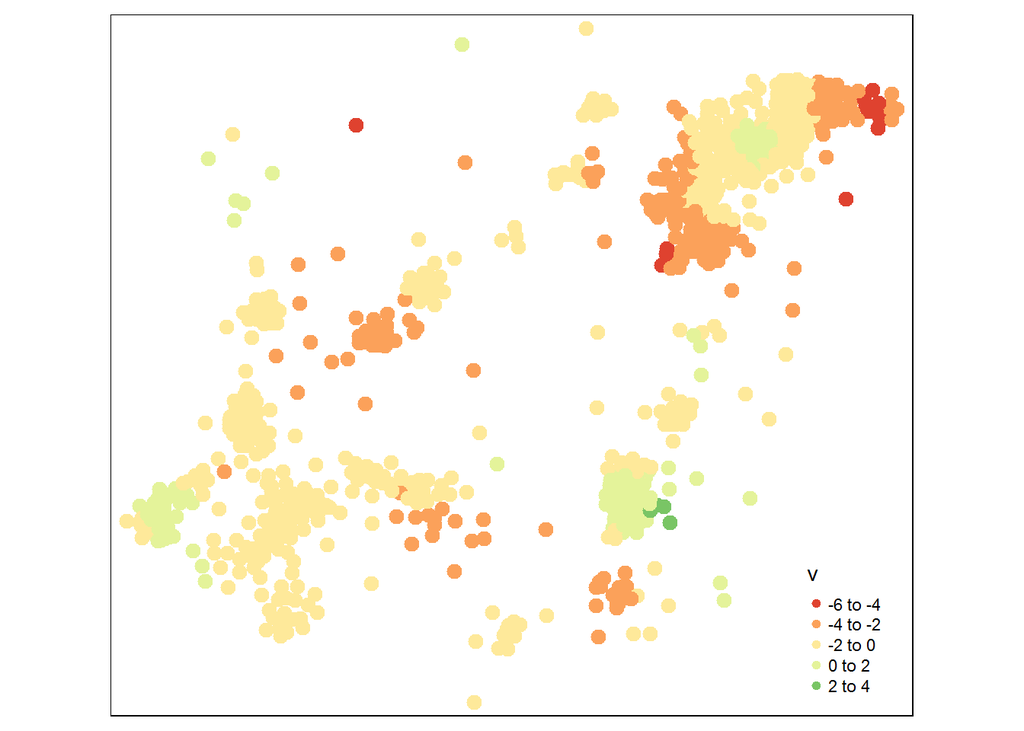

```r
#map hsppl1
v = (GWRlm$SDF$hsppl1/GWRlm$SDF$hsppl1_se)
MAPv = SpatialPointsDataFrame(data=data.frame(v), coords=xy, proj4string=CRS("+proj=robin +lon 0=0"))
qtm (shp=MAPv, symbols.col="v", symbols.shape=20)
```

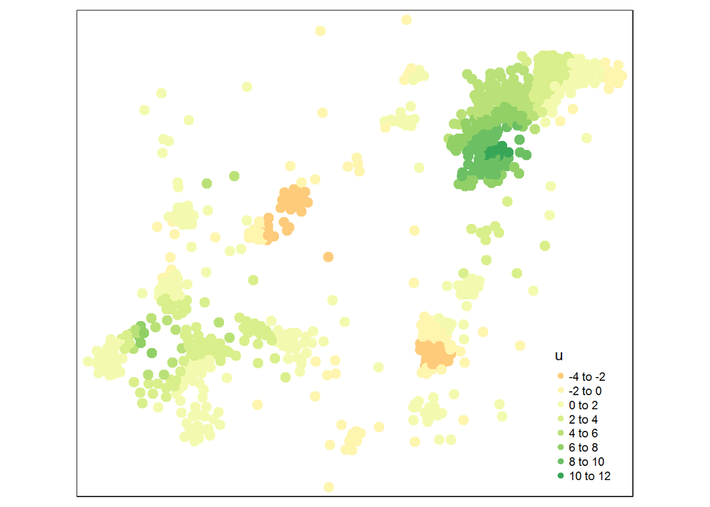

```r
#map ecplc1
u = (GWRlm$SDF$ecplc1/GWRlm$SDF$ecplc1_se)
MAPu = SpatialPointsDataFrame(data=data.frame(u), coords=xy, proj4string=CRS("+proj=robin +lon 0=0"))
qtm (shp=MAPu, symbols.col="u", symbols.shape=20)
```

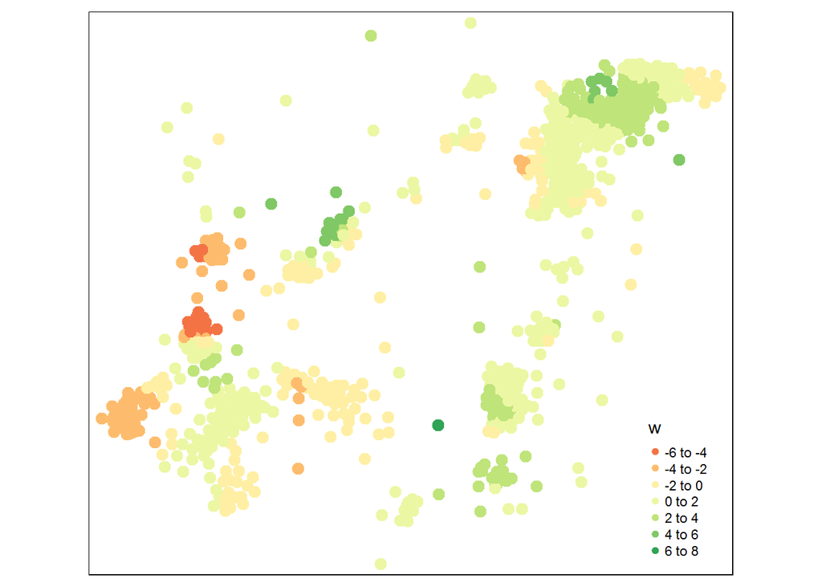

```r
#map enplc4
w = (GWRlm$SDF$enplc4/GWRlm$SDF$enplc4_se)
MAPw = SpatialPointsDataFrame(data=data.frame(w), coords=xy, proj4string=CRS("+proj=robin +lon 0=0"))
qtm (shp=MAPw, symbols.col="w", symbols.shape=20)
```

####GWR Interpretation The GWR shows how the relationships vary over space. This AIC is smaller the the spatial error model and the OLS model, so that seems like it’s the best fit for the data. For ecppl1, there are jst a couple points clusteredd in the north eastern corner that are significant. For hsppl1, there are 4 locations that are significant, which are all a single point or a couple points clustered. 3/4 of these clusters are again in the NE corner. For ecplc1, there is a much larger region, again in the NE corner that is significant, and a little region in the SW corner that is significant. Finally, for enplc4, there are a few significant clusters scattered around the plot. 3 out of 4 variables show similar significance of variation, while enplc4 seems to follow a different pattern.